# Variant Calling

Samantha M. Pacheco Gómez

2025-05-23

Disclaimer: The text in the problem section was taken from https://mimodd.readthedocs.io/en/latest/tutorial_example2.html

# 1 <sup>st</sup> Day: The problem

Wild-type laboratory strains of Saccharomyces cerevisiae, like the reference strain S288C or the widely used strain CEN.PK113-7D can grow on a variety of carbon sources including lactate.

In a publication from a few years ago<sup>1,</sup> a knock-out mutant strain based on CEN.PK113-7D was generated, in which the gene for the only known lactate transporter in yeast, jen1, is disrupted by an inserted reporter cassete. As expected, this strain cannot use lactate as a carbon source. Laboratory evolution was used then on this strain to obtain two substrains that had regained the ability to grow on lactate. Both substrains, IMW004 and IMW005, were subjected to WGS to gain insight into the genomic changes that these strains had undergone compared to CEN.PK113-7D over ~100 generations of laboratory evolution and that might explain their ability to grow on lactate despite the disruption of the jen1 gene.

Strikingly, the substrains harbored independent point mutations in the acetate transporter gene ADY2 and subsequent experiments showed that these mutations are likely to cause changes in the substrate specificity of this transporter.

Go to `/mnt/atgc-d1/bioinfoII/drobles/variant_calling/data/.` There, you will find:

- The S288C reference sequence in FASTA format (S288C_ref.fa) and its index (S288C_ref.fa.fai)
- a BAM file of NGS reads from the CEN.PK113-7D parent strain (reads are a random subset of those available through the NCBI SRA under accession number SRX129922) (SRR445715.aligned.sorted.bam) and its index (SRR445715.aligned.sorted.bam.bai)
- a BAM file of NGS reads from the lab-evolved substrain IMW004 (same reads as available under the NCBI SRA accession number SRX129995), (SRR445716.aligned.sorted.bam) and its index (SRR445716.aligned.sorted.bam.bai)
- a BAM file of NGS reads from the lab-evolved substrain IMW005 (same reads as available under the NCBI accession number SRX129996) (SRR445717.aligned.sorted.bam) and its index (SRR445717.aligned.sorted.bam.bai)
- Other files related to the work in this module (you can check the readme inside this directory if you’re curious)

We will replicate the findings of the original paper by performing variant calling and quality filtering, and using Ensembl VEP to predict variant consequences.

<sup>1</sup>Kok et al. (2012): Laboratory evolution of new lactate transporter genes in a jen1D mutant of Saccharomyces cerevisiae and their identification as ADY2 alleles by whole-genome resequencing and transcriptome analysis. FEMS Yeast Res, 12:359-74.

## 1.1 Understanding our data

```
cd mnt/atgc-d1/bioinfoII/drobles/variant_calling/data/.
module load samtools/1.10

samtools stats -r /mnt/atgc-d1/bioinfoII/drobles/variant_calling/data/S288C_ref.fa /mnt/atgc-d1/bioinfoII/drobles/variant_calling/data/SRR445715.aligned.sorted.bam > SRR445715.stats
samtools stats -r /mnt/atgc-d1/bioinfoII/drobles/variant_calling/data/S288C_ref.fa /mnt/atgc-d1/bioinfoII/drobles/variant_calling/data/SRR445716.aligned.sorted.bam > SRR445716.stats
samtools stats -r /mnt/atgc-d1/bioinfoII/drobles/variant_calling/data/S288C_ref.fa /mnt/atgc-d1/bioinfoII/drobles/variant_calling/data/SRR445717.aligned.sorted.bam > SRR445717.stats


plot-bamstats -r /mnt/atgc-d1/bioinfoII/drobles/variant_calling/data/other_files/S288C_ref.fa.gc -p SRR445715.graphs/ SRR445715.stats
plot-bamstats -r /mnt/atgc-d1/bioinfoII/drobles/variant_calling/data/other_files/S288C_ref.fa.gc -p SRR445716.graphs/ SRR445716.stats
plot-bamstats -r /mnt/atgc-d1/bioinfoII/drobles/variant_calling/data/other_files/S288C_ref.fa.gc -p SRR445717.graphs/ SRR445717.stats

scp spacheco@dna.lavis.unam.mx:/mnt/atgc-d1/bioinfoII/spacheco/dani/variant_calling/SRR44571* /home/sam/Documents/danirobles_cosas/
```

**What is the percentage of mapped reads in all three files? Check the insert size, GC content, per-base sequence content and quality per cycle graphs. Do they all look reasonable?**

### 1.1.1 Metrics

| File | Mapped.reads | Insert.size | GC.content | Per.base.sequence.content | Quality.per.cycle |
| --- | --- | --- | --- | --- | --- |
| SRR445715 | 17503811 (97.4%) | avg=212 median=217 | peaks at 40% (OK) | stable, minor imbalances at the beginning | avg Q30 or above |
| SRR445716 | 12428002 (96.6%) | avg=334.6 median=335 | peaks at 40% (OK) | stable, minor imbalances at the beginning | avg Q30 or above |
| SRR445717 | 13230229 (96.4%) | avg=336.2 median=341 | peaks at 40% (OK) | stable, minor imbalances at the beginning | avg Q30 or above |

### 1.1.2 SRR445715 – Quality Control Plots

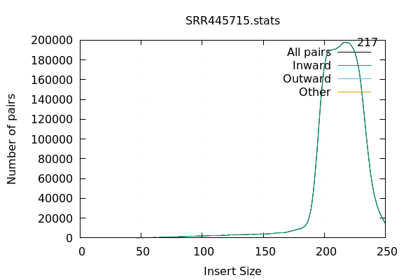

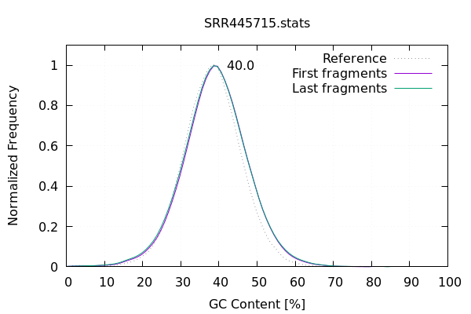

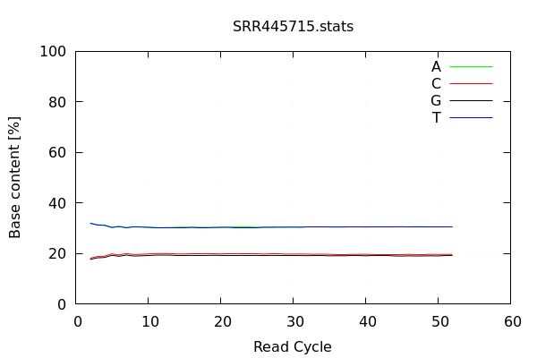

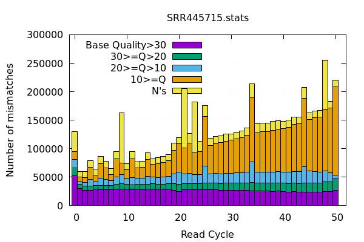

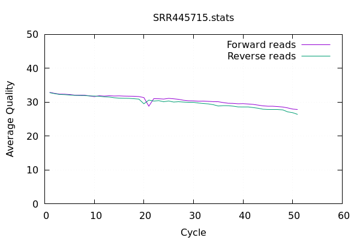

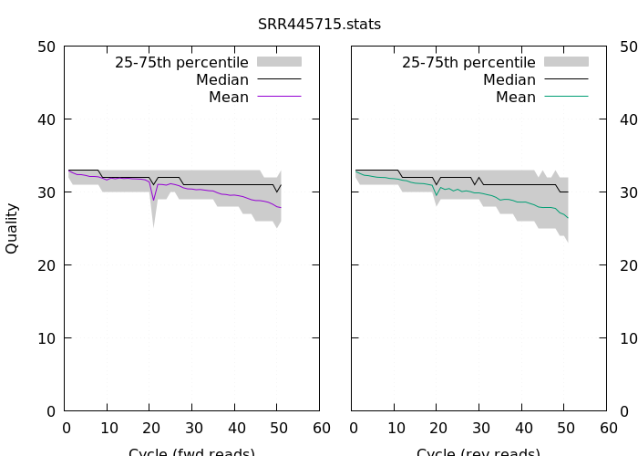

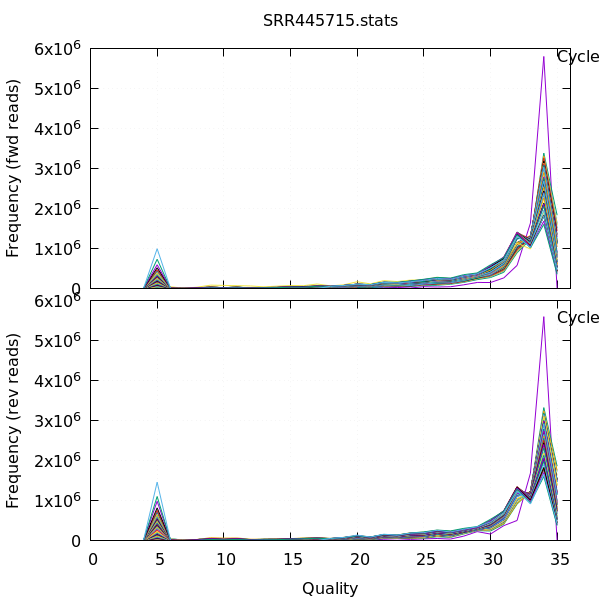

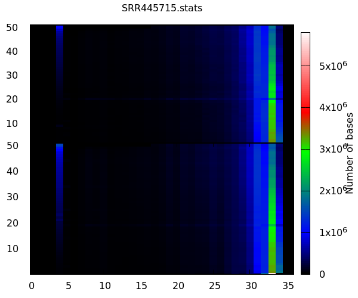

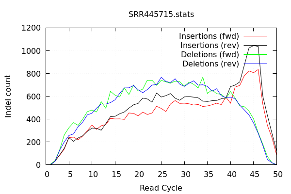

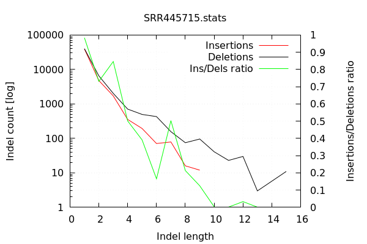

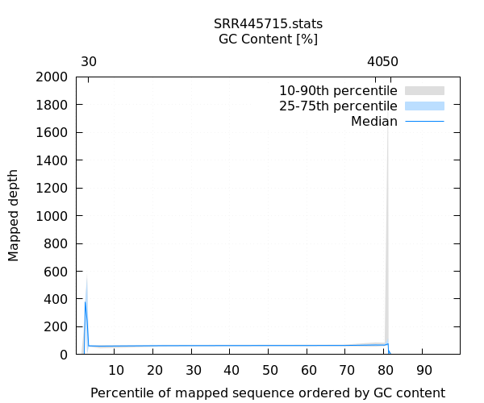

Summary:

The QC plots for SRR445715 demonstrate high sequencing and mapping quality. The insert size distribution is tight and centered at a median of 217 bp, consistent with expectations for paired-end libraries. The GC content peaks at 40% and follows a bell-shaped curve without notable bias. Per-base sequence composition is stable across the read, with only minor imbalances at the beginning that are not unusual. Quality scores per cycle average around Q30 or higher throughout most of the read, with a slight decline near the end. Although a moderate increase in mismatches and indels is seen at later cycles, this pattern is typical for Illumina reads and does not indicate problematic data. Overall, the dataset is of high quality and suitable for downstream analysis.

### 1.1.3 SRR445716 – Quality Control Plots

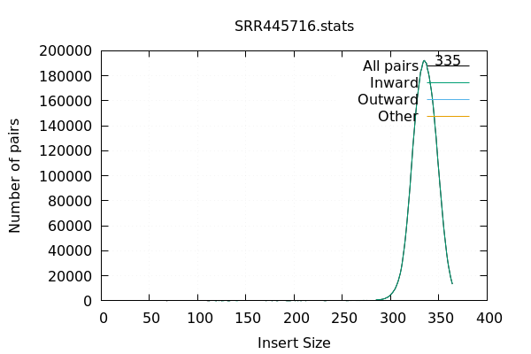

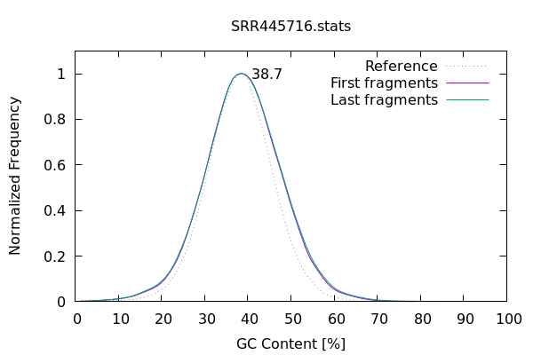

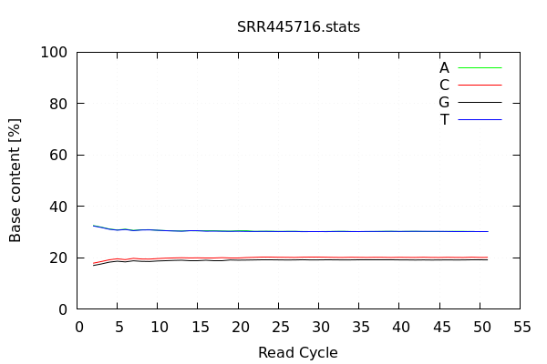

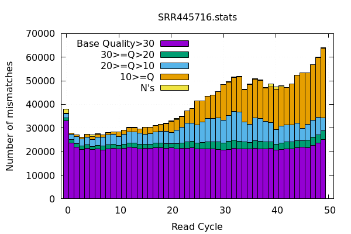

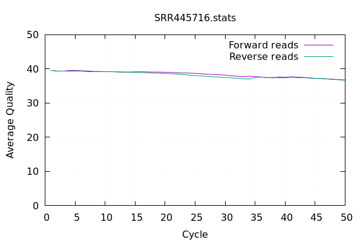

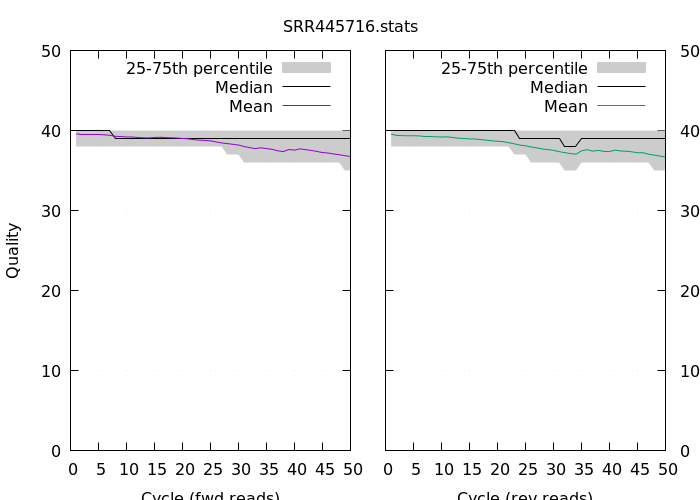

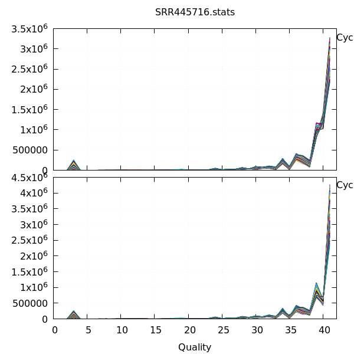

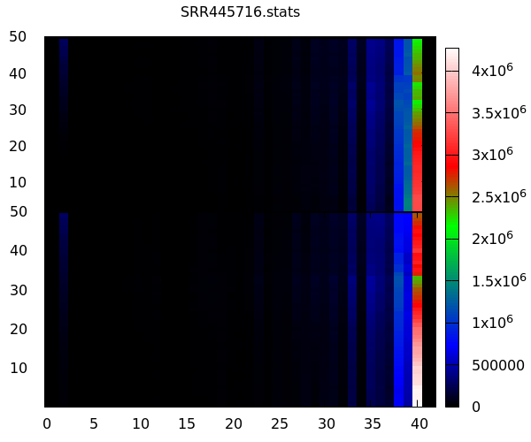

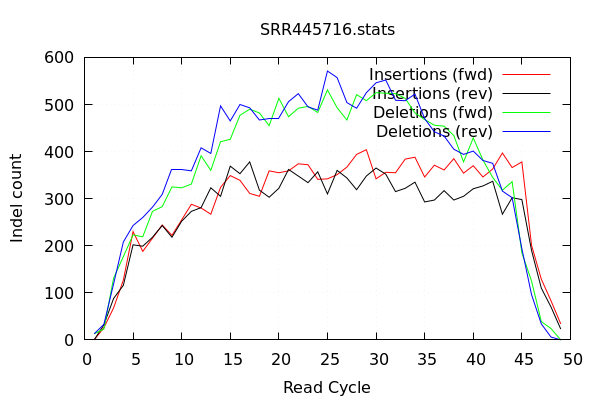

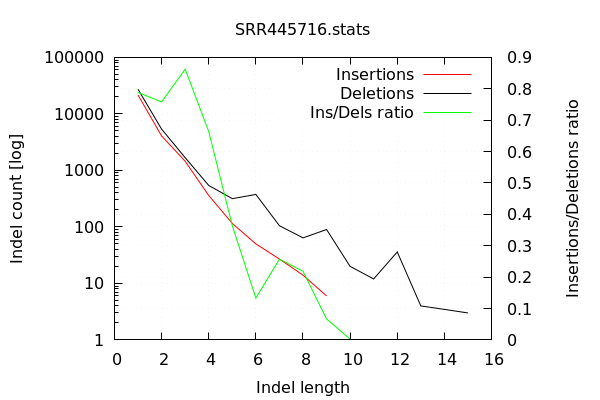

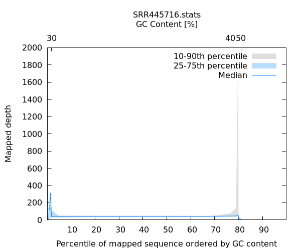

Summary:

The QC plots for SRR445716 confirm that the dataset is of high sequencing quality. The insert size distribution is unimodal and centered at a median appropriate for standard paired-end libraries. The GC content follows a smooth bell-shaped distribution, peaking near 40%, with no indication of GC-related coverage bias. Per-base sequence composition reveals slight base imbalance at the start of the reads, which stabilizes quickly and is commonly observed in Illumina libraries. Quality scores remain consistently high across the read length, with averages near or above Q30, and only a mild drop toward the end. Mismatch and indel frequencies increase moderately in later cycles, as expected, but remain within acceptable ranges. The dataset is well-suited for reliable variant calling and further genomic analysis.